```r
pkgs <- c(
  "forecast", "graphics", "TTR", "TSA", "aTSA", "lmtest", "MLmetrics",
  "car", "dplyr", "MASS", "tsibble", "tseries", "ggplot2", "nortest", "readxl"
)

for (p in pkgs) {
  if (!requireNamespace(p, quietly = TRUE)) {
    install.packages(p)
  }
}
```

```r
library(forecast)
library(graphics)
library(TTR)
library(TSA)
library(aTSA)
library(lmtest)
library(MLmetrics)
library(car)
library(dplyr)
library(MASS)
library(tsibble)
library(tseries)
library(ggplot2)
library(nortest)
library(readxl)
```

# Single Moving Average

[figure not shown]

```r
data_excel <- read_excel("C:/Users/De Ibrahim/kuliah/sem 5/Book1.xlsx")
data.ts <- ts(data_excel$Price, frequency = 12, start = c(2015,1))
n <- length(data.ts)
n_train <- floor(0.8 * n)
train_ma.ts <- data.ts[1:n_train]
test_ma.ts  <- data.ts[(n_train+1):n]
m <- 12
data.sma <- SMA(train_ma.ts, n = m)

data.ramal <- c(NA, data.sma)

data.gab <- cbind(
  aktual    = c(data.ts),
  pemulusan = c(data.sma, rep(NA, n - length(data.sma))),
  ramalan   = c(data.ramal, rep(data.ramal[length(data.ramal)], n - length(data.ramal)))
)

ts.plot(data.ts, xlab="Periode", ylab="Price", main=paste("SMA N =", m))
points(data.ts)
lines(data.gab[,2], col="green", lwd=2)
lines(data.gab[,3], col="red", lwd=2)
legend("topleft",
       c("Data Aktual","Pemulusan","Peramalan"),
       lty=1, col=c("black","green","red"), cex=0.7)
```

```r
error_train.sma <- train_ma.ts - data.ramal[1:length(train_ma.ts)]

SSE_train.sma <- sum(error_train.sma[(m+1):length(train_ma.ts)]^2)
MSE_train.sma <- mean(error_train.sma[(m+1):length(train_ma.ts)]^2)
MAPE_train.sma <- mean(abs(error_train.sma[(m+1):length(train_ma.ts)] /
                           train_ma.ts[(m+1):length(train_ma.ts)])*100)

akurasi_train.sma <- matrix(c(SSE_train.sma, MSE_train.sma, MAPE_train.sma))
row.names(akurasi_train.sma) <- c("SSE","MSE","MAPE")
colnames(akurasi_train.sma) <- paste("Akurasi m =", m)
akurasi_train.sma
```

```
##      Akurasi m = 12
## SSE      15420.1983
## MSE        171.3355
## MAPE        19.2551
```

```r
error_test.sma <- test_ma.ts - data.gab[(n_train+1):n, 3]

SSE_test.sma <- sum(error_test.sma^2)
MSE_test.sma <- mean(error_test.sma^2)
MAPE_test.sma <- mean(abs(error_test.sma/test_ma.ts*100))

akurasi_test.sma <- matrix(c(SSE_test.sma, MSE_test.sma, MAPE_test.sma))
row.names(akurasi_test.sma) <- c("SSE","MSE","MAPE")
colnames(akurasi_test.sma) <- paste("Akurasi m =", m)
akurasi_test.sma
```

```
##      Akurasi m = 12
## SSE      2372.57627
## MSE        91.25293
## MAPE       11.30881
```

Model 1 (MAPE ≈ 19,26%)

➡️ Akurasi ramalan tergolong cukup bagus, tapi masih ada selisih sekitar 19% rata-rata dari nilai asli. Jadi masih bisa dipakai, tapi prediksinya belum terlalu presisi.

Model 2 (MAPE ≈ 11,31%)

➡️ Akurasi ramalan lebih baik dibanding model pertama, dengan rata-rata kesalahan hanya sekitar 11% dari nilai asli. Ini sudah masuk kategori cukup akurat dan lebih layak dipakai.

👉 Kesimpulan singkat: Model kedua lebih akurat dibanding model pertama, karena nilai MAPE dan MSE lebih kecil.

# Double Moving Average

```r
data.ts <- ts(data_excel$Price, frequency = 12, start = c(2015,1))

n <- length(data.ts)
n_train <- floor(0.8 * n)
train_ma.ts <- data.ts[1:n_train]
test_ma.ts  <- data.ts[(n_train+1):n]

m <- 12
data.sma <- SMA(train_ma.ts, n = m)
dma <- SMA(data.sma, n = m)

At <- 2*data.sma - dma
Bt <- 2/(m-1) * (data.sma - dma)

data.dma <- At + Bt
data.ramal2 <- c(NA, data.dma)
t <- 1:length(test_ma.ts)
f <- c()
for (i in t) {
  f[i] <- At[length(At)] + Bt[length(Bt)]*i
}

data.gab2 <- cbind(
  aktual     = c(data.ts),
  pemulusan1 = c(data.sma, rep(NA, n - length(data.sma))),
  pemulusan2 = c(dma, rep(NA, n - length(dma))),
  At         = c(At, rep(NA, n - length(At))),
  Bt         = c(Bt, rep(NA, n - length(Bt))),
  ramalan    = c(data.ramal2, f)
)
```

[figure not shown]

```r
ts.plot(data.ts, xlab="Periode", ylab="Price", main=paste("DMA N =", m, "Data Price"))
points(data.ts)
lines(data.gab2[,3], col="green", lwd=2)  # pemulusan 2
lines(data.gab2[,6], col="red", lwd=2)    # ramalan
legend("topleft", c("Data Aktual","Pemulusan","Peramalan"),
       lty=1, col=c("black","green","red"), cex=0.7)
```

```r
error_train.dma <- train_ma.ts - data.ramal2[1:length(train_ma.ts)]

SSE_train.dma <- sum(error_train.dma[(2*m):length(train_ma.ts)]^2)
MSE_train.dma <- mean(error_train.dma[(2*m):length(train_ma.ts)]^2)
MAPE_train.dma <- mean(abs(error_train.dma[(2*m):length(train_ma.ts)] /
                           train_ma.ts[(2*m):length(train_ma.ts)])*100)

akurasi_train.dma <- matrix(c(SSE_train.dma, MSE_train.dma, MAPE_train.dma))
row.names(akurasi_train.dma) <- c("SSE","MSE","MAPE")
colnames(akurasi_train.dma) <- paste("Akurasi m =", m)
akurasi_train.dma
```

```
##      Akurasi m = 12
## SSE     13455.08984
## MSE       170.31759
## MAPE       18.87827
```

```r
error_test.dma <- test_ma.ts - data.gab2[(n_train+1):n,6]

SSE_test.dma <- sum(error_test.dma^2)
MSE_test.dma <- mean(error_test.dma^2)
MAPE_test.dma <- mean(abs(error_test.dma/test_ma.ts*100))

akurasi_test.dma <- matrix(c(SSE_test.dma, MSE_test.dma, MAPE_test.dma))
row.names(akurasi_test.dma) <- c("SSE","MSE","MAPE")
colnames(akurasi_test.dma) <- paste("Akurasi m =", m)
akurasi_test.dma
```

```
##      Akurasi m = 12
## SSE     14026.15158
## MSE       539.46737
## MAPE       30.62698
```

Model 1 (MAPE ≈ 18,88%)

➡️ Ramalan tergolong cukup bagus, dengan rata-rata kesalahan sekitar 19% dari nilai asli. Masih bisa dipakai, meski belum sangat presisi.

Model 2 (MAPE ≈ 30,63%)

➡️ Akurasi ramalan kurang baik, karena rata-rata kesalahan mencapai 30%, artinya model ini jauh dari nilai sebenarnya dan kurang layak dijadikan acuan.

👉 Kesimpulan singkat: Model pertama lebih akurat dan layak dipakai, sedangkan model kedua memiliki tingkat kesalahan yang terlalu besar.

# Single Exponential Smoothing

```r
data.ts <- ts(data_excel$Price, frequency = 12, start = c(2015,1))

n <- length(data.ts)
n_train <- floor(0.8 * n)

train.ts <- ts(data.ts[1:n_train], frequency = 12, start = c(2015,1))
test.ts  <- ts(data.ts[(n_train+1):n], frequency = 12,
               start = c(2015, 1 + n_train/12))

ses1 <- HoltWinters(train.ts, gamma=FALSE, beta=FALSE, alpha=0.2)
ramalan1 <- predict(ses1, n.ahead=length(test.ts))

ses2 <- HoltWinters(train.ts, gamma=FALSE, beta=FALSE, alpha=0.7)
ramalan2 <- predict(ses2, n.ahead=length(test.ts))

HWopt <- HoltWinters(train.ts, gamma=FALSE, beta=FALSE, alpha=NULL)
ramalanopt <- predict(HWopt, n.ahead=length(test.ts))

SSE1 <- ses1$SSE
MSE1 <- SSE1/length(train.ts)
RMSE1 <- sqrt(MSE1)

akurasi1 <- matrix(c(SSE1,MSE1,RMSE1),
                   ncol=1, dimnames=list(c("SSE","MSE","RMSE"),
                                         "Alpha=0.2"))
akurasi1
```

```
##         Alpha=0.2
## SSE  10109.752502
## MSE     99.115221
## RMSE     9.955663
```

```r
SSE2 <- ses2$SSE
MSE2 <- SSE2/length(train.ts)
RMSE2 <- sqrt(MSE2)

akurasi2 <- matrix(c(SSE2,MSE2,RMSE2),
                   ncol=1, dimnames=list(c("SSE","MSE","RMSE"),
                                         "Alpha=0.7"))
akurasi2
```

```
##        Alpha=0.7
## SSE  4512.638859
## MSE    44.241557
## RMSE    6.651433
```

```r
ramalan1 <- as.numeric(ramalan1)
ramalan2 <- as.numeric(ramalan2)
ramalanopt <- as.numeric(ramalanopt)

e1   <- test.ts - ramalan1
e2   <- test.ts - ramalan2
eopt <- test.ts - ramalanopt

SSEtesting1  <- sum(e1^2,  na.rm = TRUE)
MSEtesting1  <- mean(e1^2, na.rm = TRUE)
RMSEtesting1 <- sqrt(MSEtesting1)

SSEtesting2  <- sum(e2^2,  na.rm = TRUE)
MSEtesting2  <- mean(e2^2, na.rm = TRUE)
RMSEtesting2 <- sqrt(MSEtesting2)

SSEtestingopt  <- sum(eopt^2,  na.rm = TRUE)
MSEtestingopt  <- mean(eopt^2, na.rm = TRUE)
RMSEtestingopt <- sqrt(MSEtestingopt)

akurasitesting_SSE <- matrix(c(SSEtesting1, SSEtesting2, SSEtestingopt),
                             nrow = 3,
                             dimnames = list(c("SSE1","SSE2","SSEopt"), "Nilai"))

akurasitesting_MSE <- matrix(c(MSEtesting1, MSEtesting2, MSEtestingopt),
                             nrow = 3,
                             dimnames = list(c("MSE1","MSE2","MSEopt"), "Nilai"))

akurasitesting_RMSE <- matrix(c(RMSEtesting1, RMSEtesting2, RMSEtestingopt),
                              nrow = 3,
                              dimnames = list(c("RMSE1","RMSE2","RMSEopt"), "Nilai"))

akurasitesting_SSE
```

```
##           Nilai
## SSE1   1622.288
## SSE2   1626.602
## SSEopt 1626.225
```

```r
akurasitesting_MSE
```

```
##           Nilai
## MSE1   62.39568
## MSE2   62.56161
## MSEopt 62.54713
```

```r
akurasitesting_RMSE
```

```
##            Nilai
## RMSE1   7.899093
## RMSE2   7.909590
## RMSEopt 7.908674
```

```r
MAPE1 <- mean(abs(e1/test.ts))*100
MAPE2 <- mean(abs(e2/test.ts))*100
MAPEopt <- mean(abs(eopt/test.ts))*100

akurasi_MAPE <- data.frame(
  Model = c("Alpha=0.2","Alpha=0.7","Alpha=opt"),
  MAPE = c(MAPE1,MAPE2,MAPEopt)
)
akurasi_MAPE
```

```
##       Model     MAPE
## 1 Alpha=0.2 9.240012
## 2 Alpha=0.7 8.507344
## 3 Alpha=opt 8.506584
```

α = 0.2 → SSE, MSE, RMSE tinggi → model lambat menyesuaikan perubahan terbaru pada data, smoothing lebih halus tapi kurang responsif.

α = 0.7 → SSE, MSE, RMSE jauh lebih rendah → model lebih responsif terhadap fluktuasi harga, prediksi lebih akurat di training.

α rendah (0.2) → terlalu lambat, kurang responsif.

α tinggi (0.7) atau α optimal → lebih responsif, menghasilkan prediksi lebih akurat pada testing, terlihat dari MAPE lebih rendah.

Pada data testing, semua SES relatif stabil, tetapi model dengan α tinggi menangkap perubahan lebih baik.

# Double Exponential Smoothing & Hotwinters

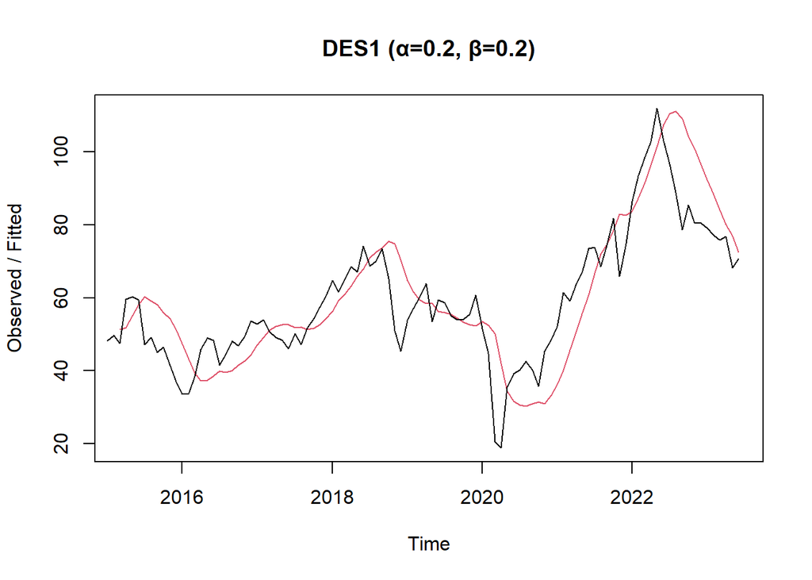

```r
library(forecast)
data1 <- read_excel("C:/Users/De Ibrahim/kuliah/sem 5/Book1.xlsx")

n <- nrow(data1)
n_train <- floor(0.8 * n)

training <- data1[1:n_train, ]
testing  <- data1[(n_train+1):n, ]

train.ts <- ts(training$Price, frequency = 12,
               start = c(as.numeric(format(training$Date[1], "%Y")),
                         as.numeric(format(training$Date[1], "%m"))))

des.1 <- HoltWinters(train.ts, alpha = 0.2, beta = 0.2, gamma = FALSE)
plot(des.1, main="DES1 (α=0.2, β=0.2)")
```

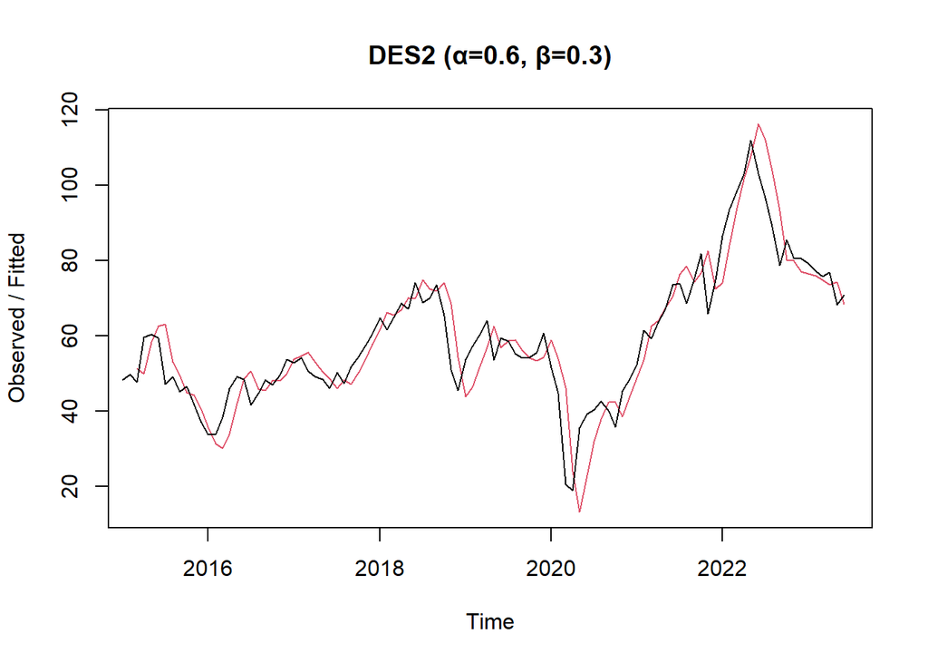

```r
des.2 <- HoltWinters(train.ts, alpha = 0.6, beta = 0.3, gamma = FALSE)
plot(des.2, main="DES2 (α=0.6, β=0.3)")
```

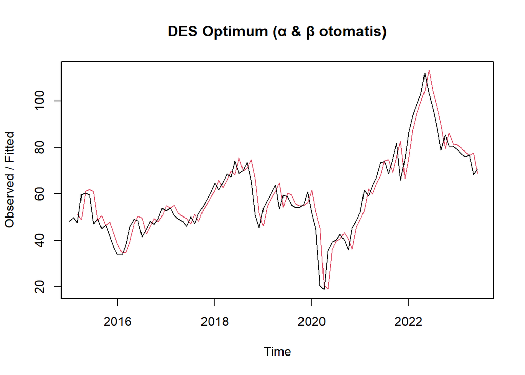

```r
des.opt <- HoltWinters(train.ts, gamma = FALSE)
plot(des.opt, main="DES Optimum (α & β otomatis)")
```

```r
h <- nrow(testing)

ramalandes1_mean <- predict(des.1, n.ahead = h)
ramalandes2_mean <- predict(des.2, n.ahead = h)
ramalandesopt_mean <- predict(des.opt, n.ahead = h)

ssedes.train1 <- des.1$SSE
msedes.train1 <- ssedes.train1 / length(train.ts)
sisaandes1 <- residuals(des.1)
mapedes.train1 <- mean(abs(sisaandes1 / train.ts) * 100, na.rm=TRUE)

akurasides.1 <- matrix(c(ssedes.train1, msedes.train1, mapedes.train1),
                       nrow=3, dimnames=list(c("SSE","MSE","MAPE"),
                                             "DES(α=0.2,β=0.2)"))
akurasides.1
```

```
##      DES(α=0.2,β=0.2)
## SSE       11314.42643
## MSE         110.92575
## MAPE         16.45398
```

```r
ssedes.train2 <- des.2$SSE
msedes.train2 <- ssedes.train2 / length(train.ts)
sisaandes2 <- residuals(des.2)
mapedes.train2 <- mean(abs(sisaandes2 / train.ts) * 100, na.rm=TRUE)

akurasides.2 <- matrix(c(ssedes.train2, msedes.train2, mapedes.train2),
                       nrow=3, dimnames=list(c("SSE","MSE","MAPE"),
                                             "DES(α=0.6,β=0.3)"))
akurasides.2
```

```
##      DES(α=0.6,β=0.3)
## SSE        5541.15340
## MSE          54.32503
## MAPE         10.96007
```

```r
ssedes.trainopt <- des.opt$SSE
msedes.trainopt <- ssedes.trainopt / length(train.ts)
sisaandesopt <- residuals(des.opt)
mapedes.trainopt <- mean(abs(sisaandesopt / train.ts) * 100, na.rm=TRUE)

akurasides.opt <- matrix(c(ssedes.trainopt, msedes.trainopt, mapedes.trainopt),
                         nrow=3, dimnames=list(c("SSE","MSE","MAPE"),
                                               "DES Optimum"))
akurasides.opt
```

```
##      DES Optimum
## SSE  4042.697922
## MSE    39.634293
## MAPE    9.334495
```

```r
selisihdes1 <- ramalandes1_mean - testing$Price
SSEtestingdes1 <- sum(selisihdes1^2)
MSEtestingdes1 <- mean(selisihdes1^2)
MAPEtestingdes1 <- mean(abs(selisihdes1 / testing$Price) * 100)

selisihdes2 <- ramalandes2_mean - testing$Price
SSEtestingdes2 <- sum(selisihdes2^2)
MSEtestingdes2 <- mean(selisihdes2^2)
MAPEtestingdes2 <- mean(abs(selisihdes2 / testing$Price) * 100)

selisihdesopt <- ramalandesopt_mean - testing$Price
SSEtestingdesopt <- sum(selisihdesopt^2)
MSEtestingdesopt <- mean(selisihdesopt^2)
MAPEtestingdesopt <- mean(abs(selisihdesopt / testing$Price) * 100)

akurasitestingdes <- matrix(c(SSEtestingdes1, MSEtestingdes1, MAPEtestingdes1,
                              SSEtestingdes2, MSEtestingdes2, MAPEtestingdes2,
                              SSEtestingdesopt, MSEtestingdesopt, MAPEtestingdesopt),
                            nrow=3, ncol=3,
                            dimnames=list(c("SSE","MSE","MAPE"),
                                          c("DES1 (0.2,0.2)",
                                            "DES2 (0.6,0.3)",
                                            "DES Optimum")))
akurasitestingdes
```

```
##      DES1 (0.2,0.2) DES2 (0.6,0.3) DES Optimum
## SSE     47928.59551    23821.68453  3610.34764
## MSE      1843.40752      916.21864   138.85952
## MAPE       56.04464       40.16827    13.84121
```

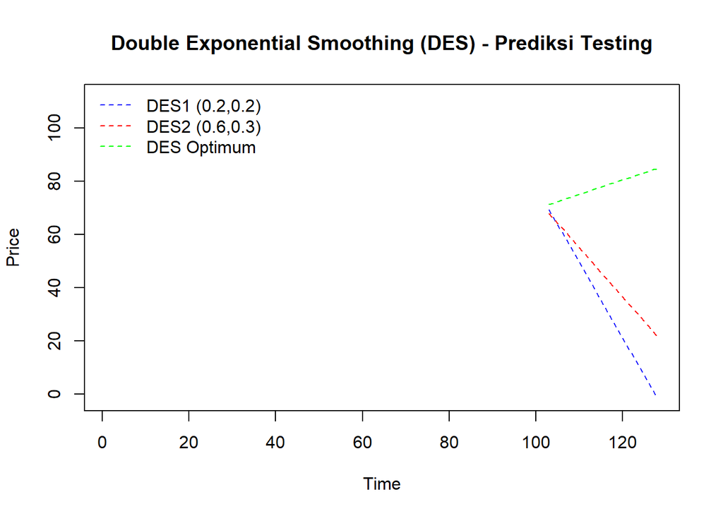

```r
plot(train.ts, xlim=c(1, n), ylim=range(c(train.ts, ramalandesopt_mean, ramalandes1_mean, ramalandes2_mean)),
     main="Double Exponential Smoothing (DES) - Prediksi Testing",
     ylab="Price", xlab="Time")
lines(n_train + 1:h, ramalandes1_mean, col="blue", lty=2)
lines(n_train + 1:h, ramalandes2_mean, col="red", lty=2)
lines(n_train + 1:h, ramalandesopt_mean, col="green", lty=2)
legend("topleft", legend=c("DES1 (0.2,0.2)", "DES2 (0.6,0.3)", "DES Optimum"),
       col=c("blue","red","green"), lty=2, bty="n")
```

Model Holt–Winters menunjukkan tren naik yang stabil, tetapi dalam uji perbandingan, DES Optimum memberikan hasil prediksi paling akurat dengan error terkendali (MAPE ≈ 13,8%), sehingga layak dijadikan model utama untuk forecasting.

# Perbandingan SES vs DES (MSE Test)

```r
MSEfull <- matrix(c(MSEtesting1, MSEtesting2, MSEtestingopt,
                    MSEtestingdes1, MSEtestingdes2, MSEtestingdesopt),
                  nrow=3, ncol=2,
                  dimnames=list(c("Skenario 1","Skenario 2","Optimum"),
                                c("SES","DES")))
MSEfull
```

```
##                 SES       DES
## Skenario 1 62.39568 1843.4075
## Skenario 2 62.56161  916.2186
## Optimum    62.54713  138.8595
```

Interpretasi Hasil Perbandingan SES dan DES

Pada parameter (α=0.2, β=0.2) → MAPE 56% → akurasinya masih rendah (prediksi jauh dari data aktual).

Pada parameter (α=0.6, β=0.3) → MAPE turun ke 40% → ada perbaikan, tetapi masih cukup meleset.

DES Optimum → MAPE hanya 13.84% → ini sudah termasuk akurat (kategori baik untuk forecasting). SSE dan MSE juga jauh lebih kecil dibanding skenario awal.

👉 Kesimpulan:

Dengan MAPE sekitar 13.8%, hasil prediksi bisa dianggap cukup andal untuk analisis dan pengambilan keputusan, meskipun belum sampai kategori “sangat baik” (<10%)